# Aligning, Clustering and Annotating Genomic Sequences

Andrew McDavid – IND419

2022-04-08

# Motivation

- Have sequences from some region. Examples: immune repertoire, germline variation, viral genomes.
- Or perhaps homologs from various species.
- Want to explore similarities/differences between sequences. Could be used to cluster them, or generate a phylogeny.
- If there is a reference, can ask how important a difference is
  - If in a gene, does it alter protein coding?
  - Is it in an evolutionarily conserved region?

# Learning objectives

1. Query and manipulate genomic information in R, e.g. genes and transcripts
2. Manipulate sequences
3. Align and cluster sequences

# Everybody’s favorite least favorite topic

[figure not shown]

We’ll download all the SARS-COV-2 sequences that have been submitted to [NCBI’s genbank](https://www.ncbi.nlm.nih.gov/labs/virus/vssi/#/virus?SeqType_s=Nucleotide&VirusLineage_ss=SARS-CoV-2,%20taxid:2697049)

The recipe for doing this is in the appendix.

# Load FASTAs

```r
knitr::opts_chunk$set(cache = TRUE, autodep = TRUE, echo = TRUE)
suppressPackageStartupMessages({
  library(Biostrings)
library(dplyr)
library(ggplot2)
library(stringr)
library(GenomicRanges)
library(forcats)
library(ggdendro)
library(ggrepel)
})
# also need rtracklayer, msa
# BiocManager::install(c('Biostrings', 'dplyr', 'ggplot2',
# 'stringr', 'GenomicRanges', 'rtracklayer', 'seqLogo', 'Mus.musculus', 'forcats', 'ggdendro', 'ggrepel'))

fasta = readDNAStringSet('data/ny_nt_2022.fasta')
genome = readDNAStringSet('data/sars-cov2-genome.fasta')
```

We’ll load a random sample of the SARS-COV2 genomic sequences that have been submitted from New York State as of 7-April-2022, as well as the reference genome as `DNAStringSets`.

Taking a look at these, they are a Bioconductor S4 object, [with a rich set of operators](https://bioconductor.org/packages/release/bioc/vignettes/Biostrings/inst/doc/BiostringsQuickOverview.pdf) that allow them to be subset, matched, and statistics calculated upon them.

```r
fasta
```

```
## DNAStringSet object of length 448:
##       width seq                                             names
##   [1] 29716 TCTAAACGAACTTTAAAATCTG...GTACAGTGAACAATGCTAGGGA MT370904
##   [2] 29882 ATTAAAGGTTTATACCTTCCCA...GGAGAATGACAAAAAAAAAAAA MT434813
##   [3] 29882 ATTAAAGGTTTATACCTTCCCA...GGAGAATGACAAAAAAAAAAAA MT304486
##   [4] 29882 ATTAAAGGTTTATACCTTCCCA...GGAGAATGACAAAAAAAAAAAA MT434794
##   [5] 29882 ATTAAAGGTTTATACCTTCCCA...GGAGAATGACAAAAAAAAAAAA MT434789
##   ...   ... ...
## [444] 29747 TTGTAGATCTGTTCTCTAAACG...ATGTGTAAAATTAATTTTAGTA ON118367
## [445] 29540 TTACGGTTTCGTCCGTGTTGCA...TGAACAATGCTAGGGAGAGCTG ON139491
## [446] 29727 CTTTTGATCTCTTGTAGATCTG...GAGCCCTAATGTGTAAAATTAA ON139443
## [447] 29724 TTGTAGATCTGTTCTCTAAACG...ATGTGTAAAATTAATTTTAGTA ON141756
## [448] 29727 CTTTTGATCTCTTGTAGATCTG...GAGCCCTAATGTGTAAAATTAA ON139326
```

There are 448 sequences.

```r
summary(width(fasta))
```

```
##    Min. 1st Qu.  Median    Mean 3rd Qu.    Max.
##   29540   29730   29772   29775   29810   29903
```

```r
genome
```

```
## DNAStringSet object of length 1:
##     width seq                                               names
## [1] 29903 ATTAAAGGTTTATACCTTCCCAG...AAAAAAAAAAAAAAAAAAAAAAA NC_045512.2 Sever...
```

We are working with full-length sequences. The refence genome is 29903 bp in length.

# Exercise

1. Extract the first 10 sequences.
2. Extract the last 10 bases.

# Visualize genomic features

Let’s see how the coding regions are arrayed.

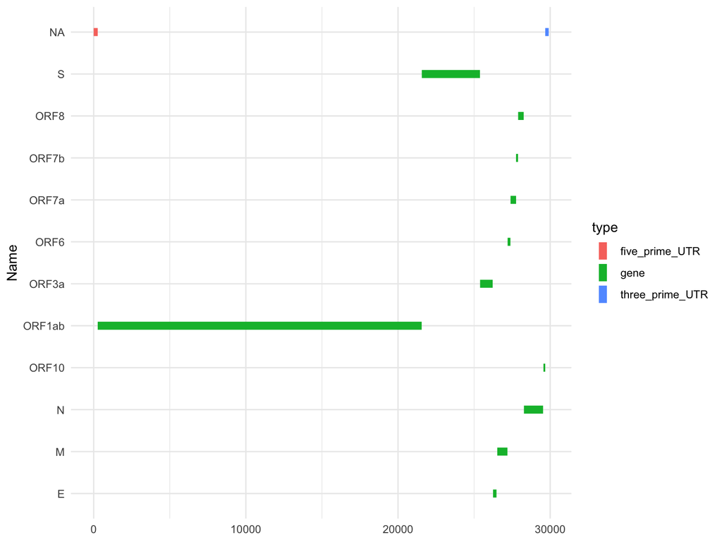

```r
anno = rtracklayer::import('data/sars-cov2.gff.gz')
anno_df = filter(as.data.frame(anno), type %in%  c('gene', 'five_prime_UTR', 'three_prime_UTR'))
anno_plot = ggplot(anno_df, aes(ymin = start, ymax = end, x= Name, color = type)) +
  geom_linerange(lwd = 3) + coord_flip() + theme_minimal()

anno_plot
```

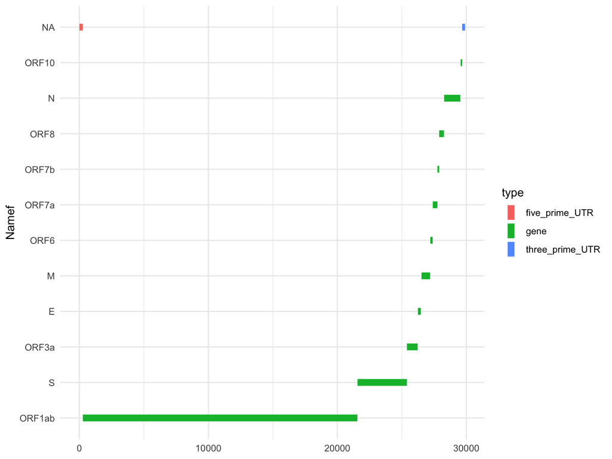

```r
anno_df = anno_df %>% mutate(Namef = fct_reorder(factor(Name), start, .fun = min))
(anno_plot %+% anno_df) + aes(x = Namef)
```

Note that in many cases your efforts might be better spent first using the ucsc genome browser.

# Using genomic information for other organisms

In the case of SARS-COV-2, I had to download a gff file with the annotations from NCBI. But in most cases a GenomicRanges object will already exist. For instance, for mouse:

```r
library(Mus.musculus)
my_entrezid = AnnotationDbi::select(org.Mm.eg.db, 'Itgax', columns = "ENTREZID", keytype = 'SYMBOL')
Itgax_region = exonsBy(TxDb.Mmusculus.UCSC.mm10.knownGene, 'gene')[[my_entrezid$ENTREZID]]
Itgax_region
```

```
## GRanges object with 36 ranges and 2 metadata columns:
##        seqnames              ranges strand |   exon_id   exon_name
##           <Rle>           <IRanges>  <Rle> | <integer> <character>
##    [1]     chr7 128129547-128129656      + |    176348        <NA>
##    [2]     chr7 128129551-128129656      + |    176349        <NA>
##    [3]     chr7 128130279-128130384      + |    176350        <NA>
##    [4]     chr7 128130817-128130920      + |    176351        <NA>
##    [5]     chr7 128131209-128131279      + |    176352        <NA>
##    ...      ...                 ...    ... .       ...         ...
##   [32]     chr7 128148230-128148313      + |    176379        <NA>
##   [33]     chr7 128148501-128148614      + |    176380        <NA>
##   [34]     chr7 128148741-128148842      + |    176381        <NA>
##   [35]     chr7 128149104-128149214      + |    176382        <NA>
##   [36]     chr7 128150099-128150657      + |    176383        <NA>
##   -------
##   seqinfo: 66 sequences (1 circular) from mm10 genome
```

Here we first access the `OrgDb` for mouse, and get the `ENTREZID` (the “column” returned) for the Itgax gene `SYMBOL`. The `OrgDB` objects are databases – you can see which keys you can search with `keytypes(org.Mm.eg.db)`, and what variables can be returned with `columns(org.Mm.eg.db)`.

Then we get all the exons for that ENTREZID id as a `GenomicRanges` object.

# Exercise

2. In Mus Musculus, determine how many different versions of transcript exist for the gene *Ptprc* (CD45). Extra credit: plot with `ggbio::autoplot`.

# Alignment

The fasta are fragments, starting and stopping at undefined positions in the SARS-COV2 genome. To do further analysis we need to put them on a common coordinates. We can do that by either aligning to a reference (fast) or constructing a denovo multiple alignment (slow, possibly intractable).

[Usearch](https://drive5.com/usearch/manual/cmds_all.html) is an extremely flexible and fast shell tool for aligning/searching/clustering sequences. It’s well worth installing a copy and learning how to use it if you need to do large-scale manipulation of sequences. Unfortunately, it is closed source, so if the documentation doesn’t explain something, you have to trust that the author has implemented it correctly. Open-sourced alternatives are available in `blast` or `cdhit.`

```bash
usearch -usearch_global data/ny_nt_2022.fasta -db data/sars-cov2-genome.fasta \
-nastout outputs/ny_nt.nast -strand plus -id .7
```

The command above aligns all the .fasta against the reference genome, and write out an aligned fasta file with each sequence the same length.

## Global vs local alignment

> An alignment [uses] basic operations that transforms a query into a reference. There are 3 different kinds of basic operations: “insertions” (gaps in query), “deletions” (gaps in reference), “replacements.”

-`?pairwiseAlignment` man page

In our command chunk below, the most important parameter is `-usearch_global`, specifying a global alignment.

```bash
usearch -usearch_global data/ny_nt_2022.fasta -db data/sars-cov2-genome.fasta  \
-nastout outputs/ny_nt.nast -strand plus -id .7
```

This means that a penalty is paid for every base in the query (`data/ny_nt_2022.fasta`) that doesn’t align to the reference `data/sars-cov2-genome.fasta`.

```r
query = c('Txe rat can',
            'The rat can',
          'The ran')
reference = 'The cat ran'
pairwiseAlignment(query[1], reference, type = 'global')
```

```
## Global PairwiseAlignmentsSingleSubject (1 of 1)
## pattern: Txe rat can
## subject: The cat ran
## score: 7.945457
```

The score here is a function of the number of matches (8) using particular scoring matrix (that should be tuned for the sequence type, eg, DNA vs Amino Acid).

```r
pairwiseAlignment(query[3], reference, type = 'global')
```

```
## Global PairwiseAlignmentsSingleSubject (1 of 1)
## pattern: The ----ran
## subject: The cat ran
## score: -3.938317
```

Now pay a penalty for opening the gap in the middle of the query.

In contrast, a local alignment looks for the highest scoring substring in query and reference, truncating each if mismatches or gaps outweigh the benefit of matching.

```r
pairwiseAlignment(query[1], reference, type = 'local')
```

```
## Local PairwiseAlignmentsSingleSubject (1 of 1)
## pattern: [3] e rat can
## subject: [3] e cat ran
## score: 10.80309
```

```r
pairwiseAlignment(query[2], reference, type = 'local')
```

```
## Local PairwiseAlignmentsSingleSubject (1 of 1)
## pattern: [1] The rat can
## subject: [1] The cat ran
## score: 16.07813
```

There are also variants of local alignments that require minimum overlaps, or of global alignments that change the end-gap penalties.

In principle, one could use `R` to align to a reference (see `pairwiseAlignment` or `stringDist`). This would be slow given the number and length of sequences we’re considering, but works fine for a few dozen sequences.

```r
ralign = pairwiseAlignment(fasta[1:10], genome, type = 'overlap')
aligned(ralign,degap = FALSE, gapCode = '-', endgapCode = '+')
```

```
## DNAStringSet object of length 10:
##      width seq
##  [1] 29903 +++++++++++++++++++++++++++++++++...+++++++++++++++++++++++++++++++++
##  [2] 29903 ATTAAAGGTTTATACCTTCCCAGGTAACAAACC...AAAAAAAAAAAA+++++++++++++++++++++
##  [3] 29903 ATTAAAGGTTTATACCTTCCCAGGTAACAAACC...AAAAAAAAAAAA+++++++++++++++++++++
##  [4] 29903 ATTAAAGGTTTATACCTTCCCAGGTAACAAACC...AAAAAAAAAAAA+++++++++++++++++++++
##  [5] 29903 ATTAAAGGTTTATACCTTCCCAGGTAACAAACC...AAAAAAAAAAAA+++++++++++++++++++++
##  [6] 29903 ATTAAAGGTTTATACCTTCCCAGGTAACAAACC...AAAAAAAAAAAA+++++++++++++++++++++
##  [7] 29903 ATTAAAGGTTTATACCTTCCCAGGTAACAAACC...AAAAAAAAAAAA+++++++++++++++++++++
##  [8] 29903 ATTAAAGGTTTATACCTTCCCAGGTAACAAACC...AAAAAAAAAAAA+++++++++++++++++++++
##  [9] 29903 +++++++++++++++++++++++++++++++++...+++++++++++++++++++++++++++++++++
## [10] 29903 +++++++++++++++++++++++++++++++++...+++++++++++++++++++++++++++++++++
```

The above code takes about a couple minutes to run, so figure that 400 sequences would take around an hour.

# Exercises

3. Consider the sequences

```r
query = 'The ran'
reference = 'The cat ran'
```

Can you modify the gap penalties so that “ran” is included in a **local alignment**?

4. Given equal gap and mismatch penalties, does the best local alignment ever return a worse score than the best global alignment?

## Multiple alignments

In the above, each sequence is aligned in turn to a reference. But in other cases, we might want to define a reference or a consensus using all sequences simultaneously. This is called a multiple alignment. It scales very poorly in the number of sequences. `kalign` is among the state of the art.

```bash
kalign -i data/ny_nt_2022.fasta -o outputs/kalign_large.out
```

This takes several hours, compared to ~20 seconds for `usearch.`

## Pairwise alignments

Previously, we aligned each of the queries to a reference, but we can also align each query to every other query giving $n(n-1)/2$ possible pairs of alignments. This can be done using global or local methods. It’s slow and memory intensive, so instead greedy approaches can be taken to cluster sequences into equivalence classes. `usearch` and `cdhit` are among the state of the art for this.

# Other organisms

In many other cases, the sequences are already aligned to a reference, in which case, the batteries are generally included for downstream analysis. If you can get a VCF file, containing the variants X samples, you are golden.

See [this workflow](https://bioconductor.org/packages/release/workflows/vignettes/variants/inst/doc/Annotating_Genomic_Variants.html) for details about how to pull out a specific gene or genes from existing annotations.

# Read padded, aligned sequences

```r
aligned = readDNAStringSet('outputs/ny_nt.nast')
aligned
```

```
## DNAStringSet object of length 448:
##       width seq                                             names
##   [1] 29903 ----------------------...---------------------- MT370904
##   [2] 29903 ATTAAAGGTTTATACCTTCCCA...A--------------------- MT434789
##   [3] 29903 ATTAAAGGTTTATACCTTCCCA...A--------------------- MT434794
##   [4] 29903 ATTAAAGGTTTATACCTTCCCA...A--------------------- MT434784
##   [5] 29903 ATTAAAGGTTTATACCTTCCCA...A--------------------- MT434796
##   ...   ... ...
## [444] 29903 ----------------------...---------------------- ON118367;ins=GAGC...
## [445] 29903 ----------------------...---------------------- ON139491
## [446] 29903 ----------------------...---------------------- ON139443
## [447] 29903 ----------------------...---------------------- ON141756
## [448] 29903 ----------------------...---------------------- ON139326
```

In any case, the output is also a FASTA file, but now each sequence is the same length, padded with `-` characters where the sequences were of differing lengths. The `-` represent beginning/trailing or internal gaps. The former are not penalized in the alignment since they just reflect that each sequence may cover a different “window”. The internal gaps, representing deletions in the query sequence, are penalized.

# Digression–figuring out how to manipulate S4 objects.

Suppose someone handed you an S4 (Bioconductor) object and didn’t write a very good manual. How could you figure out what you could do with it?

```r
str(aligned)
```

```
## Formal class 'DNAStringSet' [package "Biostrings"] with 5 slots
##   ..@ pool           :Formal class 'SharedRaw_Pool' [package "XVector"] with 2 slots
##   .. .. ..@ xp_list                    :List of 1
##   .. .. .. ..$ :<externalptr>
##   .. .. ..@ .link_to_cached_object_list:List of 1
##   .. .. .. ..$ :<environment: 0x7f9e11c39868>
##   ..@ ranges         :Formal class 'GroupedIRanges' [package "XVector"] with 7 slots
##   .. .. ..@ group          : int [1:448] 1 1 1 1 1 1 1 1 1 1 ...
##   .. .. ..@ start          : int [1:448] 1 29904 59807 89710 119613 149516 179419 209322 239225 269128 ...
##   .. .. ..@ width          : int [1:448] 29903 29903 29903 29903 29903 29903 29903 29903 29903 29903 ...
##   .. .. ..@ NAMES          : chr [1:448] "MT370904" "MT434789" "MT434794" "MT434784" ...
##   .. .. ..@ elementType    : chr "ANY"
##   .. .. ..@ elementMetadata: NULL
##   .. .. ..@ metadata       : list()
##   ..@ elementType    : chr "DNAString"
##   ..@ elementMetadata: NULL
##   ..@ metadata       : list()
```

```r
slotNames(aligned)
```

```
## [1] "pool"            "ranges"          "elementType"     "elementMetadata"
## [5] "metadata"
```

You can examine it with `str` and `slotNames`. However, in this case the `externalptr` business means nothing good will come of poking at its slots manually.

You can find out all known methods that take this object as input with something like this:

```r
showMethods(classes = class(aligned), where = 'package:Biostrings')
```

```
## Function: [ (package base)
## x="DNAStringSet", i="integer", j="missing", drop="missing"
##     (inherited from: x="List", i="ANY", j="ANY", drop="ANY")
##
## Function: [[ (package base)
## x="DNAStringSet", i="integer", j="missing"
##     (inherited from: x="List", i="ANY", j="ANY")
##
## Function: alphabetFrequency (package Biostrings)
## x="DNAStringSet"
##
## Function: coerce (package methods)
## from="ANY", to="DNAStringSet"
## from="DNAStringSet", to="QualityScaledDNAStringSet"
## from="MultipleAlignment", to="DNAStringSet"
## from="XStringViews", to="DNAStringSet"
##
## Function: complement (package Biostrings)
## x="DNAStringSet"
##
## Function: consensusString (package Biostrings)
## x="DNAStringSet"
##
## Function: dim (package base)
##
## Function: dinucleotideFrequencyTest (package Biostrings)
## x="DNAStringSet"
##
## Function: hasOnlyBaseLetters (package Biostrings)
## x="DNAStringSet"
##
## Function: initialize (package methods)
## .Object="DNAStringSet"
##     (inherited from: .Object="ANY")
##
## Function: length (package base)
## x="DNAStringSet"
##     (inherited from: x="Vector")
##
## Function: names (package base)
```

[output cut: 48 more lines]

```
##
## Function: translate (package Biostrings)
## x="DNAStringSet"
##
## Function: updateObject (package BiocGenerics)
## object="DNAStringSet"
##     (inherited from: object="XStringSet")
##
## Function: width (package BiocGenerics)
## x="DNAStringSet"
##     (inherited from: x="XVectorList")
##
## Function: windows (package IRanges)
## x="DNAStringSet"
##     (inherited from: x="XVectorList")
```

The `where = 'package:Biostrings'` can be omitted, at the cost of some irrelevant results being returned.

# Manipulating padded alignments

We can use these padded alignments to calculate consensus sequences and look for polymorphism. For instance, let’s look at the first 20 bp of the Spike gene.

```r
# First 20 bp of S gene
s_only = narrow(aligned, anno_df[which(anno_df$Name=='S'), 'start'],
                end =  anno_df[which(anno_df$Name=='S'), 'start']+20)

s_only
```

```
## DNAStringSet object of length 448:
##       width seq                                             names
##   [1]    21 ATGTTTGTTTTTCTTGTTTTA                           MT370904
##   [2]    21 ATGTTTGTTTTTCTTGTTTTA                           MT434789
##   [3]    21 ATGTTTGTTTTTCTTGTTTTA                           MT434794
##   [4]    21 ATGTTTGTTTTTCTTGTTTTA                           MT434784
##   [5]    21 ATGTTTGTTTTTCTTGTTTTA                           MT434796
##   ...   ... ...
## [444]    21 ATGTTTGTTTTTCTTGTTTTA                           ON118367;ins=GAGC...
## [445]    21 ATGTTTGTTTTTCTTGTTTTA                           ON139491
## [446]    21 ATGTTTGTTTTTCTTGTTTTA                           ON139443
## [447]    21 ATGTTTGTTTTTCTTGTTTTA                           ON141756
## [448]    21 ATGTTTGTTTTTCTTGTTTTA                           ON139326
```

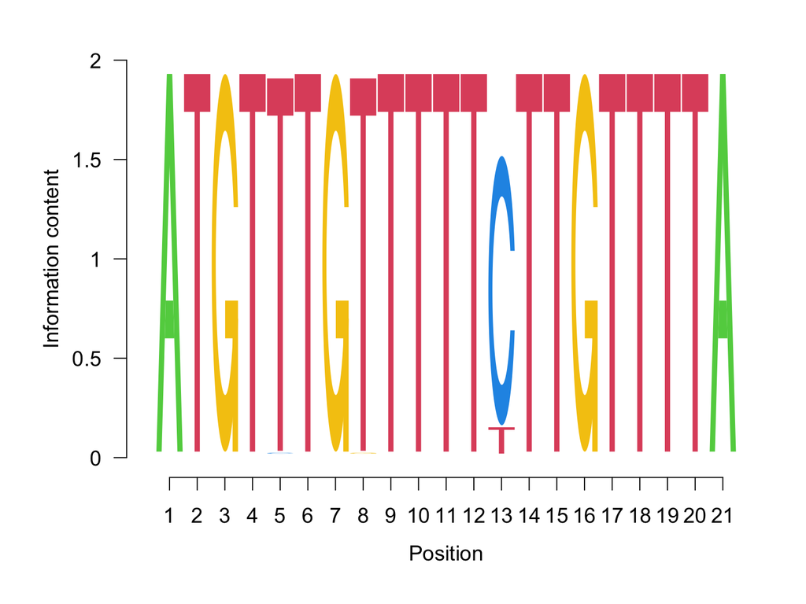

```r
cm = consensusMatrix(s_only,  baseOnly = TRUE)[1:4,]
normalized = t(t(cm)/colSums(cm))
seqLogo::seqLogo(normalized)
```

Most bases are invariant, with the exception of base 13.

# Polymorphism

```r
cm = consensusMatrix(aligned,  baseOnly = TRUE)[1:4,]
maf = tibble(maf = apply(cm, 2, function(x) 1-max(x)/sum(x)), pos = seq_along(maf))
maf = maf %>% mutate(gene = anno_df[findInterval(pos, anno_df$start), 'Namef']) %>% filter(!is.na(gene))
```

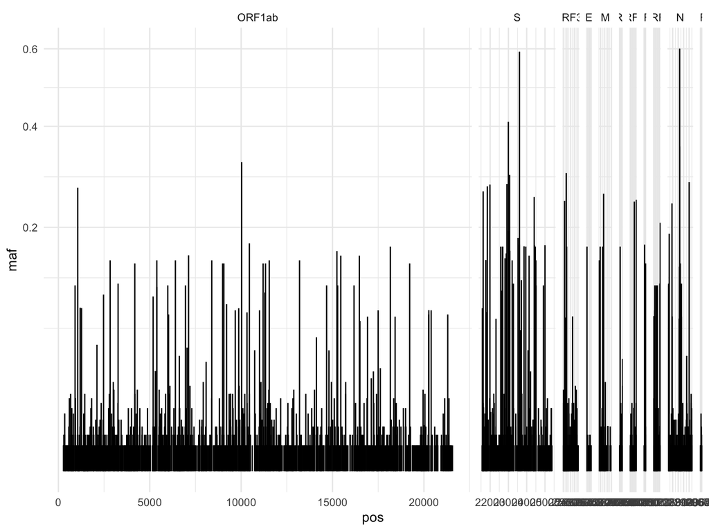

```r
maf_plot = ggplot(maf, aes(x = pos, xend = pos, yend= maf))+ theme_minimal() + facet_grid( ~ gene, scales = 'free', space = 'free')
maf_plot +geom_segment(y =0) + scale_y_sqrt()
```

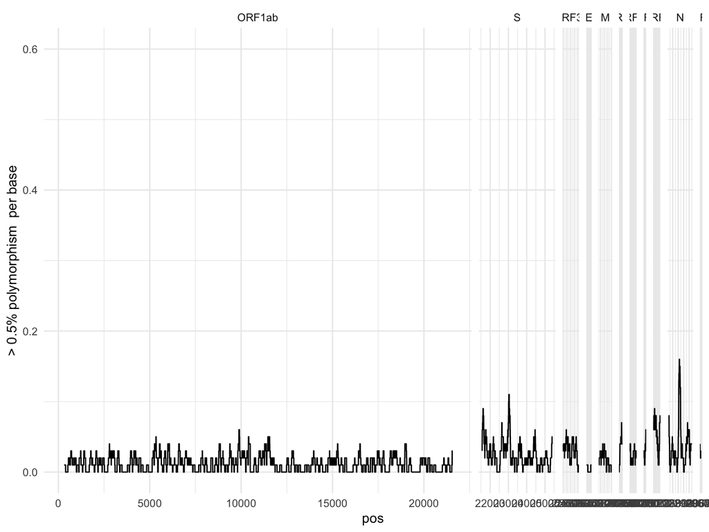

```r
maf_plot + aes(y = stats::filter(maf > 0.005, rep(1/100, 100))) +
  geom_path() + ylab('> 0.5% polymorphism  per base')
```

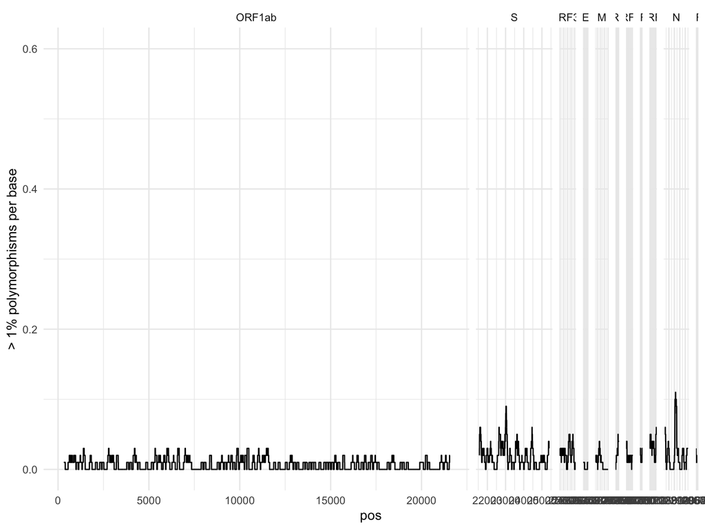

```r
maf_plot + aes(y = stats::filter(maf > 0.01, rep(1/100, 100))) +
  geom_path() + ylab('> 1% polymorphisms per base')
```

Most of the genome has low rates of polymorphism with a few notable exceptions.

# Clustering: convert gaps to wildcards

Finally, we can do some clustering of the sequences.

```r
genic_only = narrow(aligned, start = filter(anno_df, type == 'gene') %>% pull(start) %>% min(),
                    end =  filter(anno_df, type == 'gene') %>% pull(end) %>% max())
genic_only_wild = chartr(old = '-', new="N", genic_only)
```

We’ll convert the gaps to “N”s in order to not have them penalized in calculating string distances and take only complete sequences. Note that we really want to only convert leading/trailing gaps to match as wildcards. The code below does this, but is a rather nasty hack involving regular expressions. We narrowed the sequence to trim off the UTR, so shouldn’t have an issue with gaps at the start and end.

```r
genic_only_wild = lapply(genic_only, function(x){
    sx = as.character(x)
    sl = str_locate(sx, '^-*')
    sr = str_locate(sx, '-*$')
    if(sr[2] >= sr[1]) str_sub(sx, sr[1], sr[2]) = paste(rep('N', sr[2]-sr[1]+1), collapse = '')
    if(sl[2] >= sl[1])
    str_sub(sx, sl[1]+1, sl[2]) = paste(rep('N', sl[2]-sl[1]), collapse = '')
    as(sx, 'DNAString')
})
```

# Clustering: setup metadata

```r
fastanames = tibble(Accession = names(genic_only))
meta = readr::read_csv('data/sequence_meta_2022.csv')
fastanames = left_join(fastanames, meta)
```

We’ll extract the Accession from the fasta header, and join it to a csv file containing other info about the sequence.

```r
stringDist_fixed = function(x){
  res = lapply(x, function(y) neditStartingAt(y, x, fixed = FALSE))
  as.dist(matrix(unlist(res), nrow = length(x), dimnames = list(names(x), names(x))))
  }
```

We also have to hack a little function to calculate the hamming distance, ignoring wildcards.

```r
dists = stringDist_fixed(genic_only_wild)
summary(dists)
```

```
##    Min. 1st Qu.  Median    Mean 3rd Qu.    Max.
##    0.00   34.00   49.00   49.21   66.00  105.00
```

# Clustering II

There are gaps in collection, corresponding to troughs between surges.

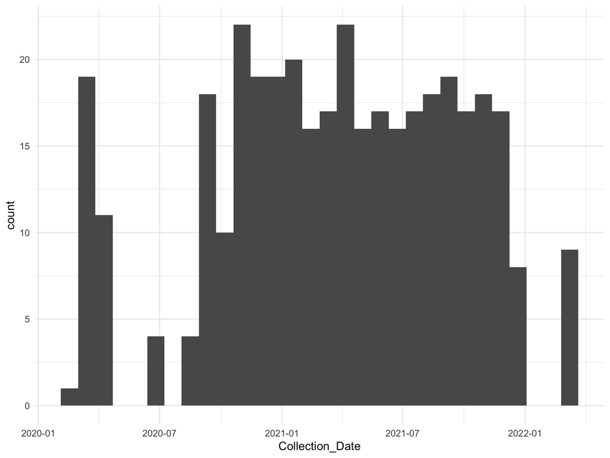

```r
ggplot(fastanames, aes(x = Collection_Date)) +
  geom_histogram() + theme_minimal()
```

Do we see segregation of the sequence?

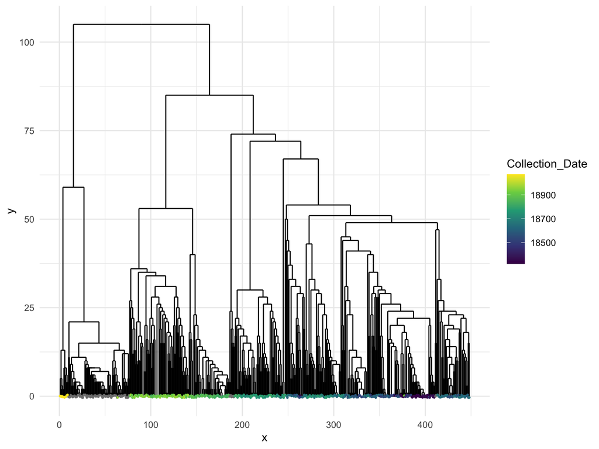

```r
hc = hclust(dists)
ddata = dendro_data(hc)
ddata$labels = left_join(ddata$labels, fastanames, by = c(label = 'Accession'))

p = ggplot(segment(ddata)) +
  geom_segment(aes(x = x, y = y, xend = xend, yend = yend)) +
   geom_jitter(data = ddata$labels, aes(x = x, y = y, color = Collection_Date), size = .5) +
  theme_minimal() +
  scale_color_viridis_c()
p
```

# PCA

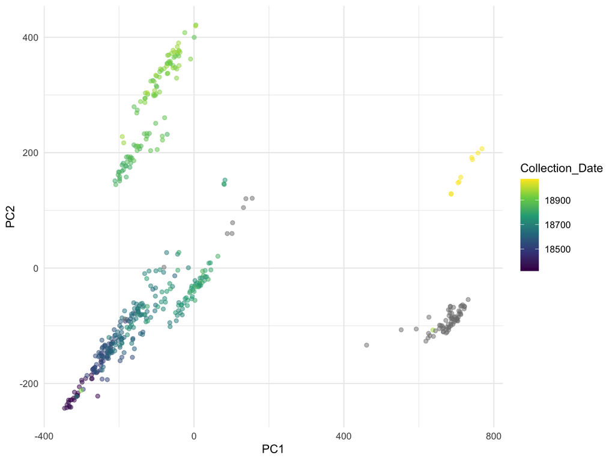

```r
pr = prcomp(as.matrix(dists), retx = TRUE)

pc_meta = cbind(pr$x[, 1:2], fastanames)
plt = ggplot(pc_meta, aes(x = `PC1`, y= `PC2`, color = Collection_Date)) +
  geom_jitter(alpha = .5, width = 10, height = 5) + theme_minimal() +
  scale_color_viridis_c()

plt
```

```r
plt + aes(color = Pangolin) +
  scale_color_discrete() + theme(legend.pos = 'none')
```

[output not shown]

[figure not shown]

Last, and probably least (since the phylogenetic tree seems much more informative) we can plot principal components.

# Appendix

```r
library(Biostrings)
library(readr)
library(dplyr)
library(lubridate)

if(!dir.exists('data')) dir.create('data')
if(!file.exists('data/ny_nt_2022.fasta')){
    download.file('https://www.ncbi.nlm.nih.gov/genomes/VirusVariation/vvsearch2/?fq=%7B!tag=SeqType_s%7DSeqType_s:(%22Nucleotide%22)&fq=VirusLineageId_ss:(2697049)&fq=%7B!tag=Completeness_s%7DCompleteness_s:(%22complete%22)&fq=&fq=%7B!tag=USAState_s%7DUSAState_s:(%22NY%22)&fq=%7B!tag=SLen_i%7DSLen_i:(%5B29000%20TO%2030000%5D)&cmd=download&sort=CollectionDate_s%20asc,SourceDB_s%20desc,CreateDate_dt%20desc,id%20asc&dlfmt=fasta&fl=AccVer_s,Definition_s,Nucleotide_seq', destfile = 'data/ny_nt_2022.fasta')
}

if(!file.exists(('data/sequence_meta_2022.csv'))){
  download.file('https://www.ncbi.nlm.nih.gov/genomes/VirusVariation/vvsearch2/?fq=%7B!tag=SeqType_s%7DSeqType_s:(%22Nucleotide%22)&fq=VirusLineageId_ss:(2697049)&fq=%7B!tag=Completeness_s%7DCompleteness_s:(%22complete%22)&fq=&fq=%7B!tag=USAState_s%7DUSAState_s:(%22NY%22)&fq=%7B!tag=SLen_i%7DSLen_i:(%5B29000%20TO%2030000%5D)&cmd=download&sort=CollectionDate_s%20asc,SourceDB_s%20desc,CreateDate_dt%20desc,id%20asc&dlfmt=csv&fl=Accession:id,Submitters:Authors_csv,Release_Date:CreateDate_dt,Pangolin:Lineage_s,PangoVersions,Random_Sampling:BaselineSurveillance_s,Isolate:IsolateParsed_s,Species:VirusSpecies_s,Molecule_type:GenomicMoltype_s,Length:SLen_i,Nuc_Completeness:Completeness_s,Geo_Location:CountryFull_s,Country:Country_s,USA:USAState_s,Host:Host_s,Isolation_Source:Isolation_csv,Collection_Date:CollectionDate_s', destfile = 'data/sequence_meta_2022.csv')
}


if(!file.exists('data/sars-cov2-genome.fasta')){
  download.file('https://ftp.ncbi.nlm.nih.gov/genomes/all/GCF/009/858/895/GCF_009858895.2_ASM985889v3/GCF_009858895.2_ASM985889v3_genomic.fna.gz', destfile = 'data/sars-cov2-genome.fasta.gz')
  system2('gunzip', args = 'data/sars-cov2-genome.fasta.gz')
}

if(!file.exists('data/sars-cov2.gff.gz')){
  download.file('https://ftp.ncbi.nlm.nih.gov/genomes/all/GCF/009/858/895/GCF_009858895.2_ASM985889v3/GCF_009858895.2_ASM985889v3_genomic.gff.gz', destfile = 'data/sars-cov2.gff.gz')
}

meta = read_csv("data/sequence_meta_2022.csv")
meta_sub = meta %>% mutate(year_week = {
  w = lubridate::week(Collection_Date)
  y = lubridate::year(Collection_Date)
  sprintf("%4.0d, week %02d", y, w)
}) %>% group_by(year_week) %>% slice_sample(n = 5)

fasta_all = Biostrings::readDNAStringSet('~/Downloads/sequences.fasta')
names(fasta_all) = stringr::str_extract(names(fasta_all), "^[0-9A-Z]+(;ins.+)?")
fasta = fasta_all[meta_sub$Accession]
Biostrings::writeXStringSet(fasta, 'data/ny_nt_2022.fasta')
Biostrings::writeXStringSet(fasta[1:20], 'data/small.fasta')
```

If you wanted to do this for real, you should use the much more complete, and annotated data at [gisaid.org] and more closely follow the pipeline at [nextrain.org’s github](https://github.com/nextstrain/ncov).